# Minimal Residual Disease in ALL – First Round Survey Results

Michaela Kotrová

m.kotrova@med2.uni-kiel.de

Last updated: 2025-05-09 11:26

# Updates

- 1 new response included (H.P.), survey closed for new responses
- New Delphi Poll Statements to download 📥
- Separate analysis for central diagnostics in pediatric and adult ALL
  - Diagnostic cytomorphology
  - Follow-up cytomorphology
  - Diagnostic flow cytometry
  - Flow MRD
  - Molecular MRD
- Time-points summary
- Treatment protocols summary
- Added tables with data to:
  - ALL patient groups
  - Study groups

# Responders

| # | First_name | Last_name |
| --- | --- | --- |
| 1 | Julia | Alten |
| 2 | Monika | Brüggemann |
| 3 | Mireia | Camós |
| 4 | Gianni | Cazzaniga |
| 5 | Emmanuelle | Clappier |
| 6 | Conny | Eckert |
| 7 | Sarah | Elitzur |
| 8 | Nicola | Gökbuget |
| 9 | Csongor | Kiss |
| 10 | Heike | Pfeifer |
| 11 | Josep Maria | Ribera |
| 12 | Nick | Short |
| 13 | Dave | Teachey |
| 14 | Jan | Trka |
| 15 | Bela | Wrench |
| 16 | Vincent | van der Velden |

# 1 Patient population and treatment protocol

## 1.1 Which ALL patient group do you primarily work with?

### 1.1.1 Plot

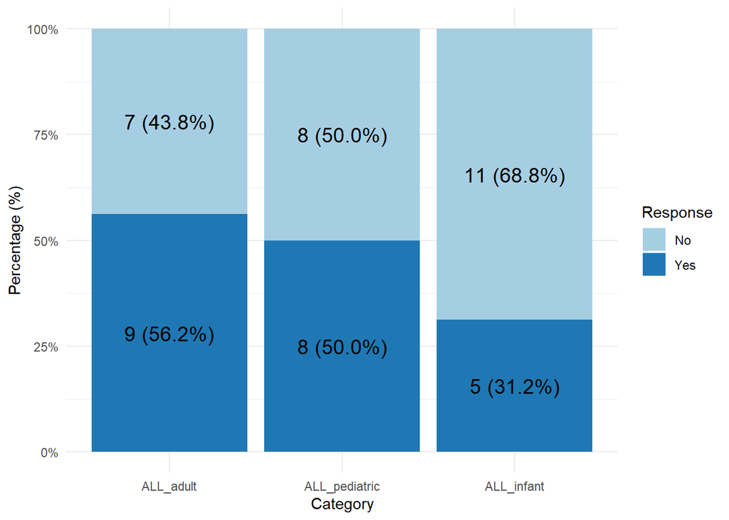

### 1.1.2 Table

| First_name | Last_name | ALL_adult | ALL_pediatric | ALL_infant | ALL_other |
| --- | --- | --- | --- | --- | --- |
| Nick | Short | Yes | No | No |  |
| Josep Maria | Ribera | Yes | No | No |  |
| Monika | Brüggemann | Yes | No | No |  |
| Vincent | van der Velden | Yes | No | No |  |
| Nicola | Gökbuget | Yes | No | No |  |
| Gianni | Cazzaniga | No | Yes | Yes |  |
| Emmanuelle | Clappier | Yes | No | No |  |
| Jan | Trka | Yes | Yes | Yes |  |
| Csongor | Kiss | No | Yes | No |  |
| Mireia | Camós | No | Yes | No |  |

[output cut: 6 more lines]

## 1.2 Which clinical study group do you represent?

### 1.2.1 Plot

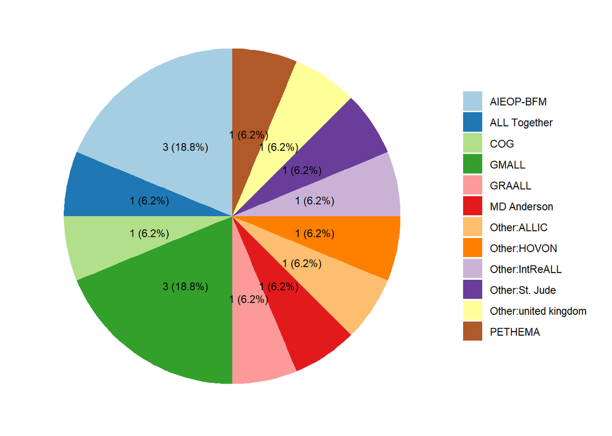

### 1.2.2 Table

| First_name | Last_name | study_group_combined |
| --- | --- | --- |
| Nick | Short | MD Anderson |
| Josep Maria | Ribera | PETHEMA |
| Monika | Brüggemann | GMALL |
| Vincent | van der Velden | Other:HOVON |
| Nicola | Gökbuget | GMALL |
| Gianni | Cazzaniga | AIEOP-BFM |
| Emmanuelle | Clappier | GRAALL |
| Jan | Trka | AIEOP-BFM |
| Csongor | Kiss | Other:ALLIC |
| Mireia | Camós | ALL Together |

[output cut: 6 more lines]

## 1.3 Which treatment protocol are your patients primarily treated under during first-line therapy?

- MD Anderson protocols - HCVAD+blina+/-INO, mini-hyper-CVD+ino+blina, blina+ponatinib
- PETHEMA ALL2019 PETHEMA ALLPh 2022
- GMALL Regstry, GMALL Evolve, GMALL BLIVEN
- HOVON-100 study protocol (if unfit: according to Hovon-117/UKALL XII study protocol (unfit arm))
- GMALL Registry younger GMALL Registry older GMALL Evolve
- AIEOP-BFM ALL 2017, Interfant-21, EsPhALL/COG, IntReALL (SR and HR)
- GRAALL/GRAAPH-2014 EWALL-INO EWALL-Ph03
- AIEOP BFM 2017
- BFM ALL-IC 2022
- ALL Together EsPhALL for Ph+ B-ALL
- AALL1731, AALL1732, AALL2331, AALL2321
- first-line: AIEOP BFM ALL 2017, ALLTogether 1 second line: IntReALL 2010 HR, ALL-REZ BFM Registry, soon IntReALL BCP 2920, HemiSmart

  We only work with the second line therapy protocols.
- INITIALL; SJALL23H; SJALL23T; Total 17
- UKALL 14
- GMALL-Register-Empfehlungen GMALL-EVOLVE
- AIEOP-BFM ALL 2017 (AIEOP-BFM ALL in general) EsPhALL/COG Interfant-21

### 1.3.1 Summary

#### 1. North American Protocols

**MD Anderson protocols**  
- HCVAD + blinatumomab (± inotuzumab)  
- mini-Hyper-CVD + inotuzumab + blinatumomab  
- blinatumomab + ponatinib

**Children’s Oncology Group (COG) & St. Jude**  
- AALL1731, AALL1732, AALL2331, AALL2321  
- INITIALL; SJALL23H; SJALL23T; Total 17

#### 2. European Protocols

**Germany (GMALL)**  
- GMALL Registry - GMALL Registry younger - GMALL Registry older - GMALL Evolve  
- GMALL BLIVEN

**Germany (BFM)** - AIEOP-BFM ALL 2017 - BFM ALL-IC 2022

**Spain (PETHEMA)**  
- PETHEMA ALL 2019  
- PETHEMA ALLPh 2022

**France (GRAALL)**  
- GRAALL/GRAAPH-2014

**Netherlands/UK (HOVON/UKALL)**  
- HOVON-100  
- HOVON-117 / UKALL XII (unfit arm)  
- UKALL 14

**Pan-European**  
- EWALL-INO  
- EWALL-Ph03  
- HEM-iSMART - EsPhALL/COG - ALLTogether 1 - Interfant-21  
- IntReALL

**Second-Line / Relapsed Protocols**  
- IntReALL 2010 HR  
- ALL-REZ BFM Registry  
- IntReALL BCP 2920  
- HEM-iSMART

# 2 Centralized vs. Local Processing of Samples

## 2.1 Is **cytomorphology** analysis performed centrally for your **diagnostic** samples?

### 2.1.1 All

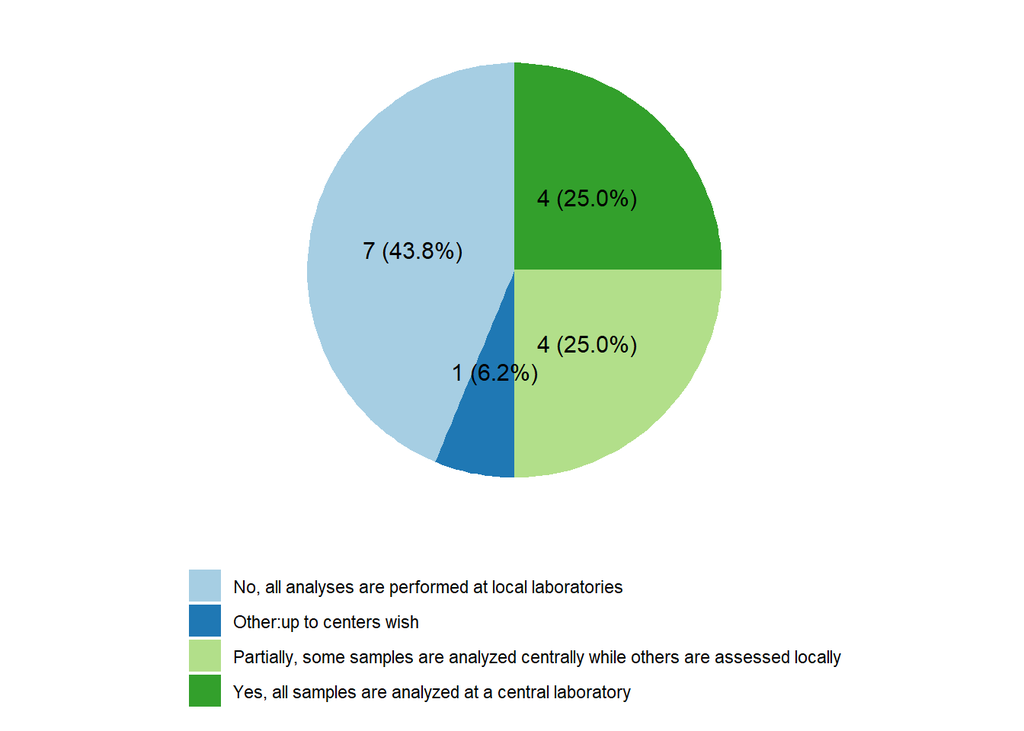

### 2.1.2 Adult vs. Pediatric

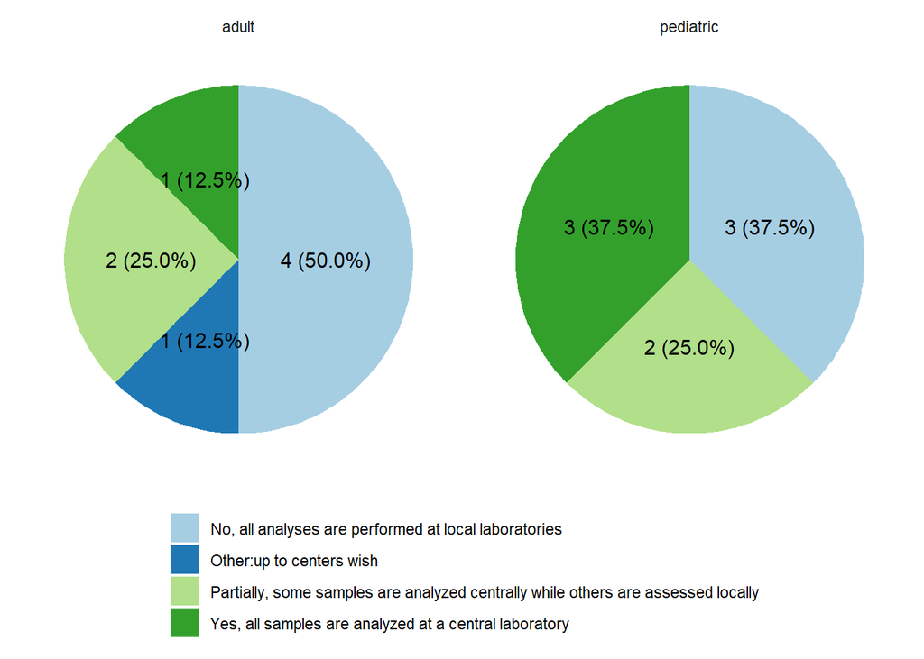

## 2.2 Is **cytomorphology** analysis performed centrally for your **follow-up** samples?

### 2.2.1 All

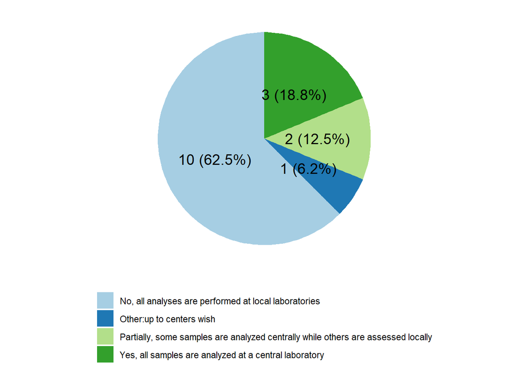

### 2.2.2 Adult vs. Pediatric

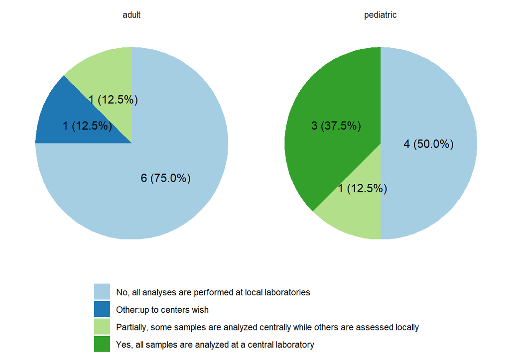

## 2.3 Is the **diagnostic immunophenotyping by flow cytometry** performed centrally for your samples?

### 2.3.1 All

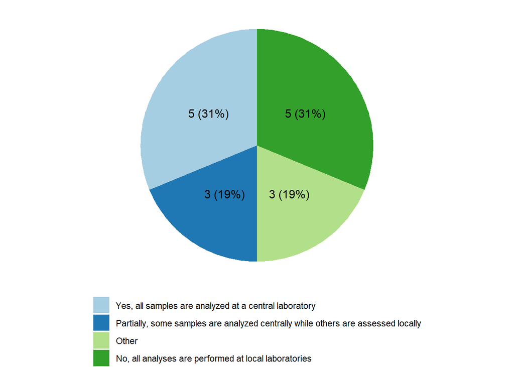

| Category | Comment |
| --- | --- |
| Other | It is recommended that immunophenotyping is performed in a central lab, but it is only prtially done centrally |
| Other | All samples are analyzed by accredited, “matured” national central laboratories. |
| Other | Diagnostic flow is centralized in 11 reference laboratories |

### 2.3.2 Adult vs. Pediatric

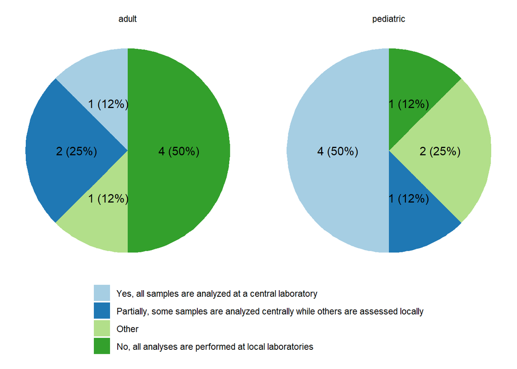

| Age_group | Category | Comment |
| --- | --- | --- |
| adult | Other | It is recommended that immunophenotyping is performed in a central lab, but it is only prtially done centrally |
| pediatric | Other | All samples are analyzed by accredited, “matured” national central laboratories. |
| pediatric | Other | Diagnostic flow is centralized in 11 reference laboratories |

## 2.4 Is **flow cytometric MRD analysis** performed centrally for your samples?

### 2.4.1 All

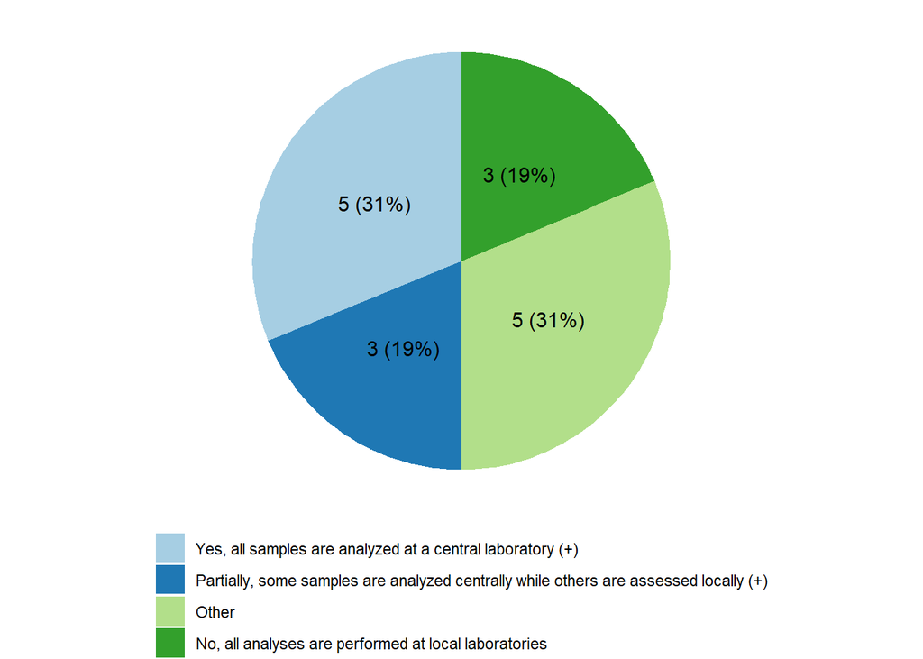

| Category | Comment |
| --- | --- |
| Other | MRD Flow is only done if no molecular MRD marker is available |
| Other | All centralized except Monza center. |
| Other | See reply to previous Q. |
| Other | Flow-MRD is centralized in 11 reference laboratories |
| Other | B-ALL on trial: COG approved labs. Off study local labs. Infant and T-ALL are central labs. |

### 2.4.2 Adult vs. Pediatric

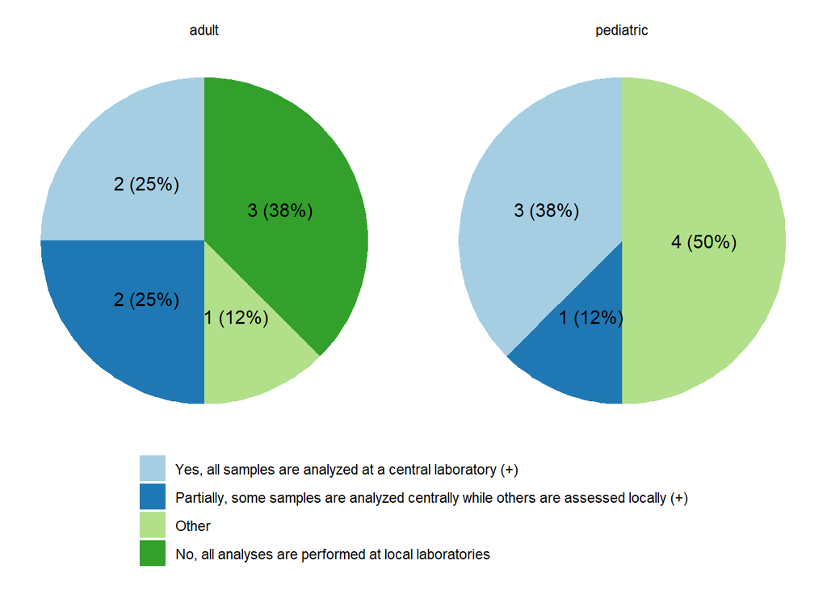

| Age_group | Category | Comment |
| --- | --- | --- |
| adult | Other | MRD Flow is only done if no molecular MRD marker is available |
| pediatric | Other | All centralized except Monza center. |
| pediatric | Other | See reply to previous Q. |
| pediatric | Other | Flow-MRD is centralized in 11 reference laboratories |
| pediatric | Other | B-ALL on trial: COG approved labs. Off study local labs. Infant and T-ALL are central labs. |

## 2.5 Is **molecular MRD** analysis performed centrally for your samples?

### 2.5.1 All

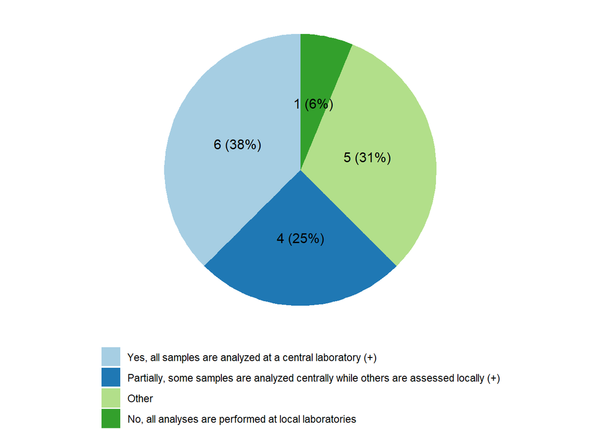

| Category | Comment |
| --- | --- |
| Other | Ig/TC central, BCR::ABL partly central |
| Other | All centralized except Padua center |
| Other | Molecular MRD is being performed as reasearch projects by some ALLIC national team laboratories. The method is not yet available for diagnostic purposes. |
| Other | Molecular-MRD is centralized in 2 accredited laboratories at H. Sant Joan de Deu (Barcelona) and H. Niño Jesús (Madrid) |
| Other | Molecular MRD is performed in subsets of patients with B-ALL |

### 2.5.2 Adult vs. Pediatric

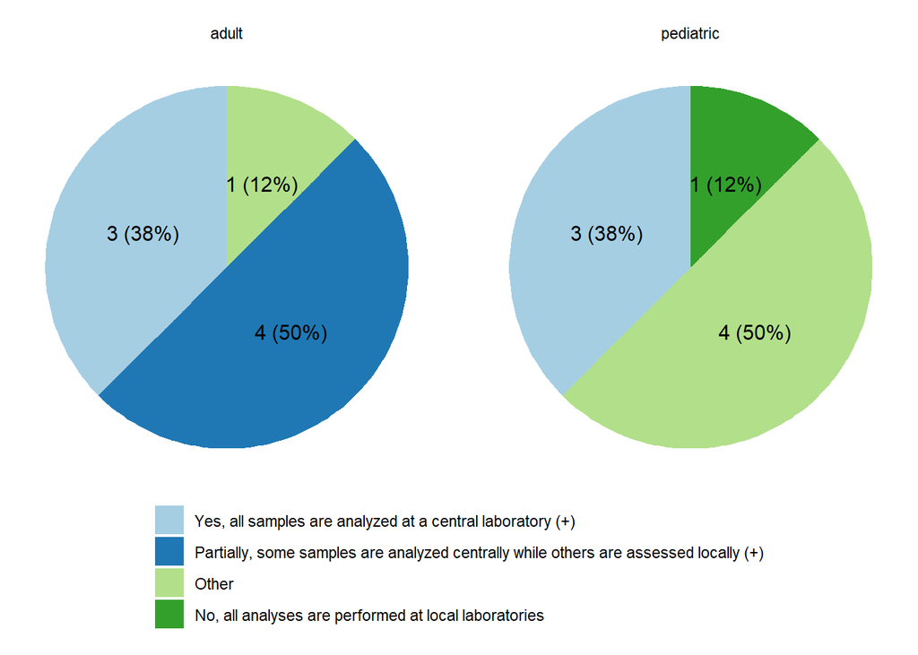

| Age_group | Category | Comment |
| --- | --- | --- |
| adult | Other | Ig/TC central, BCR::ABL partly central |
| pediatric | Other | All centralized except Padua center |
| pediatric | Other | Molecular MRD is being performed as reasearch projects by some ALLIC national team laboratories. The method is not yet available for diagnostic purposes. |
| pediatric | Other | Molecular-MRD is centralized in 2 accredited laboratories at H. Sant Joan de Deu (Barcelona) and H. Niño Jesús (Madrid) |
| pediatric | Other | Molecular MRD is performed in subsets of patients with B-ALL |

## 2.6 Are central Flow Cytometry and Molecular MRD analyses performed in the same central laboratory or in separate laboratories?

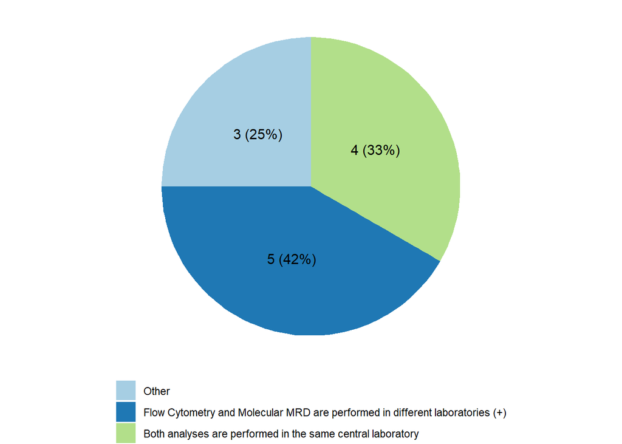

| Category | Comment |
| --- | --- |
| Other | partly overlapping |
| Other | Flow-MRD and molecular-MRD are performed in the same lab only in the 2 molecular reference labs. For the rest of patients, samples are sent for the corresponding Flow-MRD lab and one of the two accred… |

## 2.7 If Flow Cytometry and Molecular MRD analyses are performed in two different laboratories, how is the sample handled?

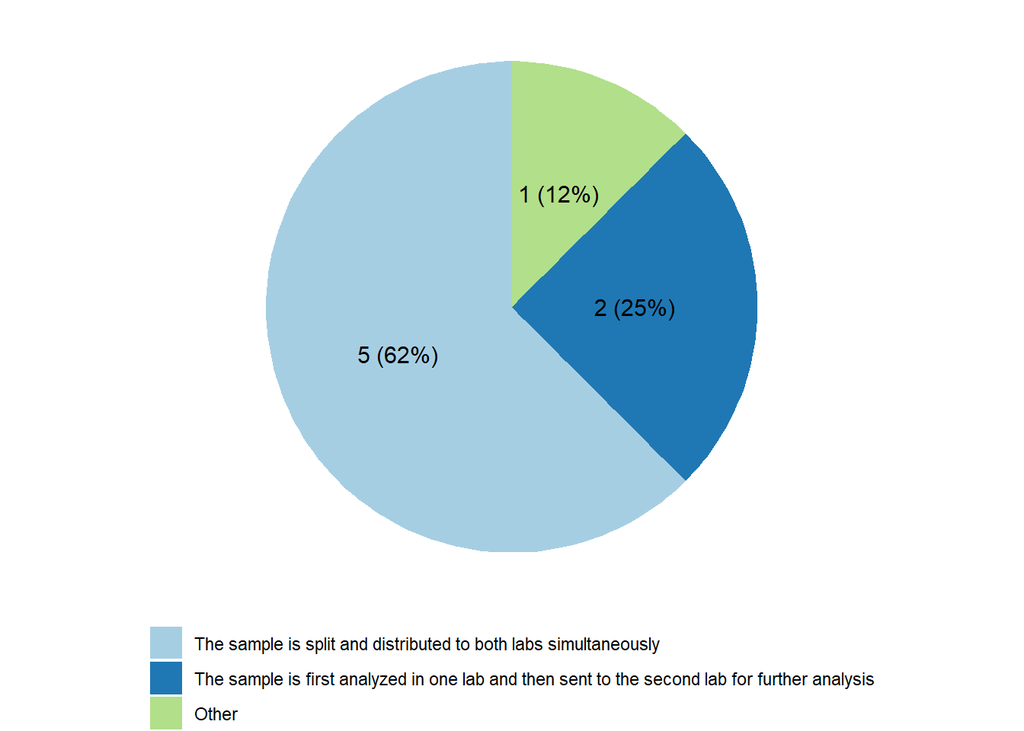

| Category | Comment |
| --- | --- |
| Other | several vials are taken. In theory the first sample should be send to molecular MRD (except day 15) and the second/third sample to Flow Cytometry and Moelcular genetics. |

# 3 MRD-based risk/treatment stratification during first-line treatment

Statement 1: MRD assessment should be performed not only in complete remission but also to complement cytomorphological evaluation in non-remission samples.

## 3.1 What time points are defined in your protocol for performing bone marrow aspiration for remission assessment and/or risk stratification?

- End of Consolidation (2 times)
- End of Induction (2 times)
- Afrterinterphase
- After consolidation A (younger) after consolidation I (elderly)
- After consolidation B (younger) after remission induction II (elderly)
- after consolidation I
- After Consolidation I
- after each consolidation block (at count recovery)
- After HR-1’ when hematopoiesis has recovered (HR only)
- After HR-2’ when hematopoiesis has recovered (HR only)
- After HR-3’ when hematopoiesis has recovered (HR only)
- after induction during relapse treatment
- after intensification (at count recovery)
- After intenstification 1A (younger) after consolidation II (elderly)
- after phase 1 induction (at count recovery)
- after phase 2 induction (at count recovery)
- After remission induction I
- After the first three HR blocks (HR1, HR2, HR3) each if CR was not achieved ealier, or previous MRD was <1% but >/= 0.1%
- Ater intensification 1B (Younger)
- Before Consolidation I
- before stem cell transplantation during relapse treatment
- D15 (mid-induction)
- D33 (EOI)
- D78 (end-of-early-intensification, i.e. PIB)
- day +15
- Day 15 (only Flow-MRD) (all risk groups)
- Day 15 bone marrow
- Day 15 of Induction (FCM-MRD)
- Day 29, before consolidation 1 (all risk groups)
- Day 33 (End of Induction IA) (PCR-MRD; FCM-MRD in case of missing Ig/TCR Targets)
- day 33 (post induction)
- Day 50; day 65/71/78 (according to MRD d29 & d50); post-nelarabine (day 87/92/99); post-NOPHO block A, B, C; before HSCT (HR-T-cell)
- Day 57, day 99 (DS-HR)
- Day 71/78, block A1; day 92, block A1; day 99, block B1; day 113, block B1, day 120, block C1; day 134, block C1; day 176, block B2; day 197, block C2, before HSCT (HR)
- Day 78, consolidation 2 (IR-low, IR-high, DS-IR)
- Day 78/Day 92 (End of Consolidation) (PCR-MRD; FCM-MRD in case of missing Ig/TCR Targets)
- Day 8 peripheral blood
- End early consolidation
- End induction
- End late consoloidation or Month 3 after alloHSCT
- End of consolidation, day +252
- end of Consolidation, day +78/+92
- End of cycle 4, day +84
- end of Induction, day +33
- End of induction, day+21
- Every 6 monys for the second year (chemotheraoy or alloHSCT)
- Every three months after late consolidation of ater alloHSCT (1st year)
- Mid induction
- nach Konsolidation 1
- Some trials have additional timepoints but it varies significantly
- vor Konsolidation 1
- week 12 (in non-SR patients)

### 3.1.1 Summary

- **Induction Phase**
  - Day 8: Mid Induction
  - Day 15: Mid Induction
  - Day 21: End of Induction
  - Day 29: Before Consolidation I
  - Day 33: End of Induction
- **Consolidation Phase**
  - Day 78: End of Consolidation
  - After the first three HR blocks (HR1, HR2, HR3)
- …

## 3.2 What are the relevant cut-off values used for risk stratification?

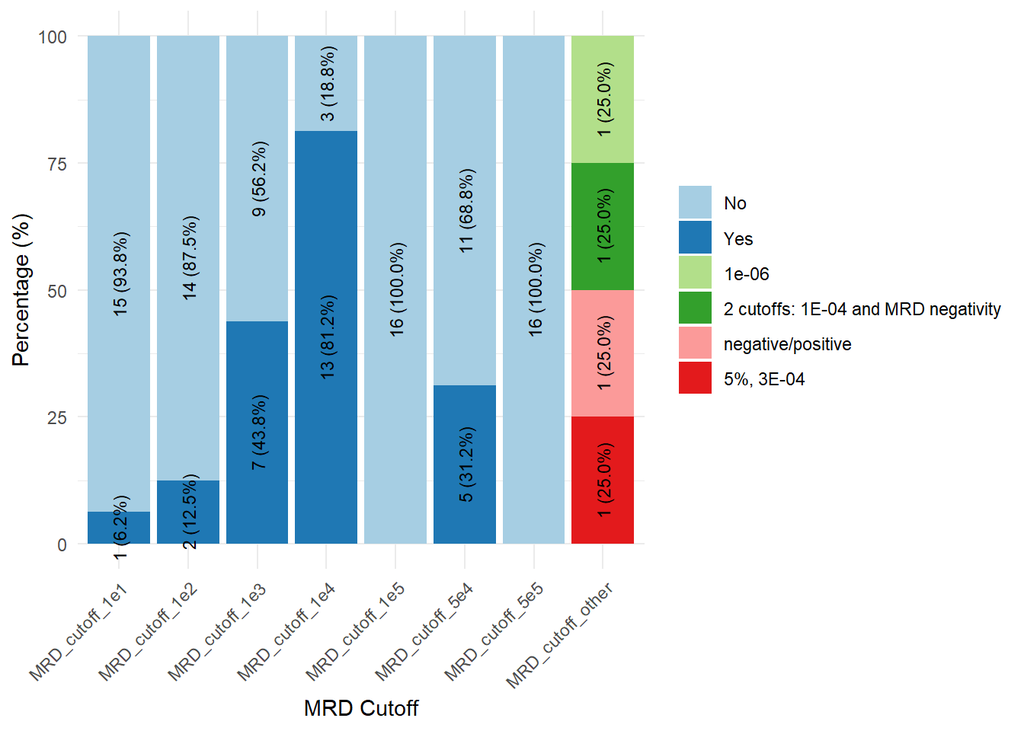

Statement 2: MRD thresholds below 1×10⁻⁴ are not relevant for risk stratification in frontline treatment of ALL.

# 4 Postremission MRD monitoring for detection of an MRD relapse

## 4.1 In which patients do you typically perform bone marrow aspiration for an early detection of an MRD relapse?

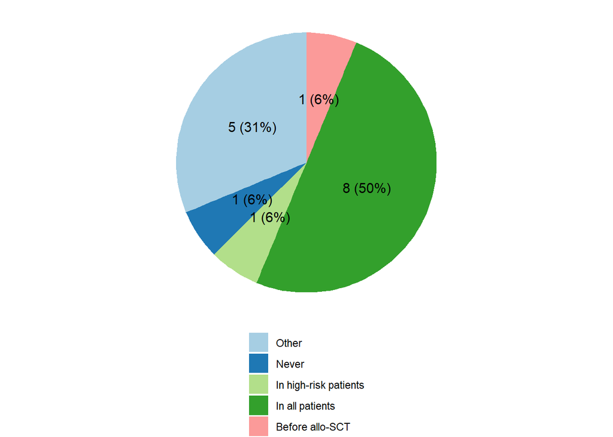

| Category | Comment |
| --- | --- |
| Other | Not systematically performed |
| Other | before and after allo-SCT, after relapse, after CART |
| Other | We follow the protocol. Additionally, in case of relapse suspicion based on clinical or laboratory findings |
| Other | Before and after allo-SCT |
| Other | all because all are relapses |

Statement 3: Bone marrow aspiration should be performed in all patients for postremission MRD monitoring to enable early detection of relapse.

## 4.2 How many times do you perform bone marrow aspiration for relapse detection **according to your protocol**?

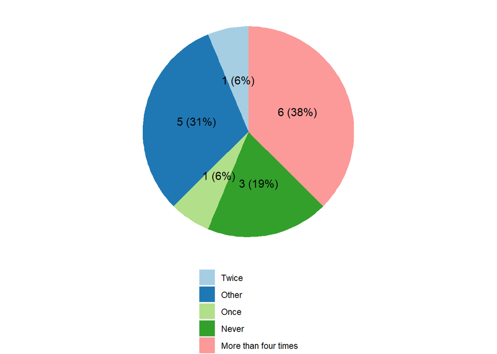

| Category | Comment |
| --- | --- |
| Other | depends on a situation, can be more than four times, follow up post-SCT is usually day30, day 60, day 180, 1 yr, 2yr, 3yr |
| Other | Never. Transplant is not included on our trials. |
| Other | currentl not defined, very frequent |
| Other | within the first year after each block |
| Other | depending of the MRD-kinetics and the risk profile (3-5 x in HR without alloHSCT and 8-10 x in pts with alloHSCT) |

## 4.3 Do you conduct additional MRD assessments based on individual clinical decisions?

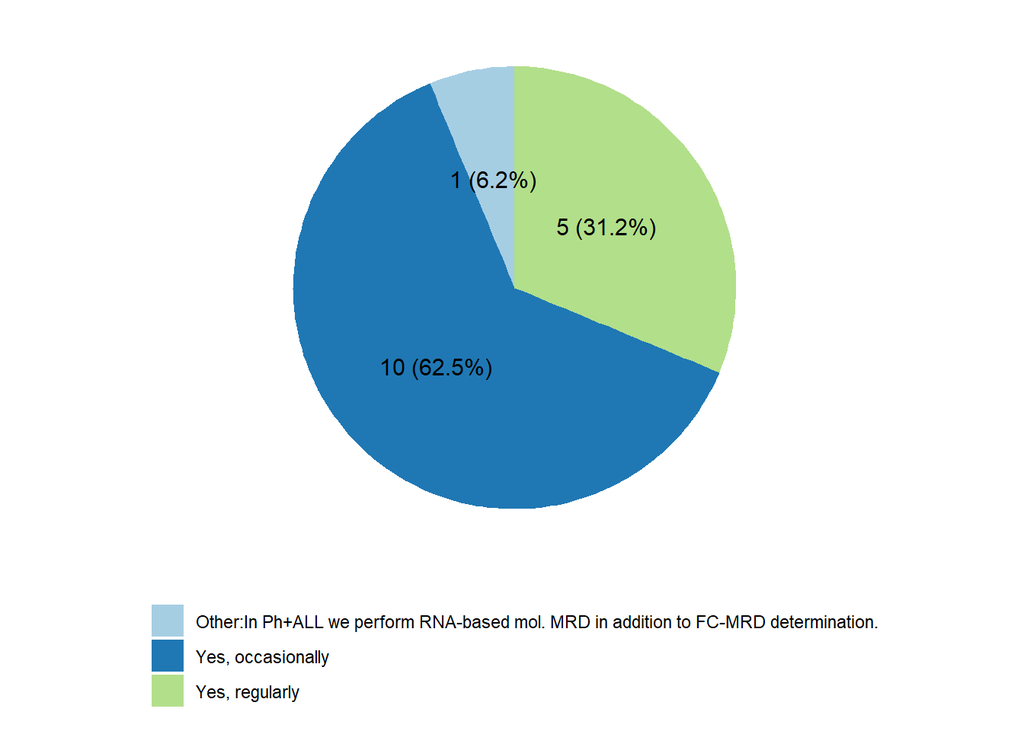

## 4.4 At what intervals per patient do you perform post-remission MRD assessment for detection of an MRD relapse?

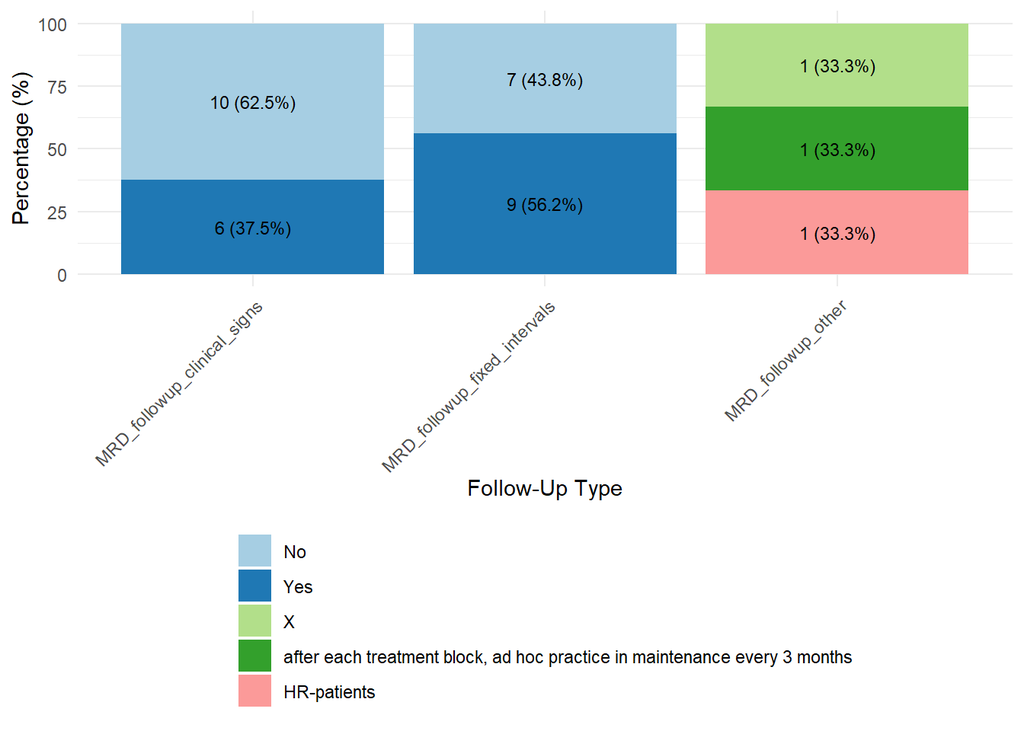

| Category | Comment |
| --- | --- |
| Clinical Signs | prolonged cytopenias |
| Clinical Signs | Standard risk (after TP1)/Medium risk patients (after TP2): Only if there are clincal or laboratory signs of relapse (e.g. prolonged cytopenia…) |
| Fixed Intervals | Every 3-4 months |
| Fixed Intervals | evry three months at 1st year, every six months for the 2nd year and then yearly up to 5 years |
| Fixed Intervals | Ph negative ALL, chemotherapy: first year: prior to each consolidation cycle, second+third year: every 3 months, fourth year: evey 6 months. Ph negative ALL, after SCT: every 3 months. Ph+ ALL, after … |
| Fixed Intervals | every 3 months (three years)/ 2 months (2 years), and if there are clinical signs of relapse |
| Fixed Intervals | 3 |
| Fixed Intervals | depends on a situation, follow up post-SCT is usually day 30, day 60, day 180, 1 yr, 2yr, 3yr, in relapsed based on relapse protocol |
| Fixed Intervals | end of therapy |
| Fixed Intervals | alle 3 Monate und bei klinischem Verdacht |
| Fixed Intervals | MRD post alloHSCT (d+30, d+60, d+100, d+180, d+365) |
| Other | If there are clinical/lab signs suspicious for relapse, and in pts. after alloHSCT |
| Other | after each treatment block, ad hoc practice in maintenance every 3 months |
| Other | MRD after each element of HR-Therapy (AIEOP-BFM:all HR-patients: TPHR1, TPHR2, TPHR3 (=MRD after each HR-Block), additionally all HR-T-ALL, all Infants, B-ALL (not atl east 2 x negative in subsequent … |

Statement 4: Postremission MRD assessment should be performed at fixed intervals according to the protocol and additionally in response to clinical signs of relapse.

## 4.5 Until when do you perform bone marrow aspiration for relapse detection?

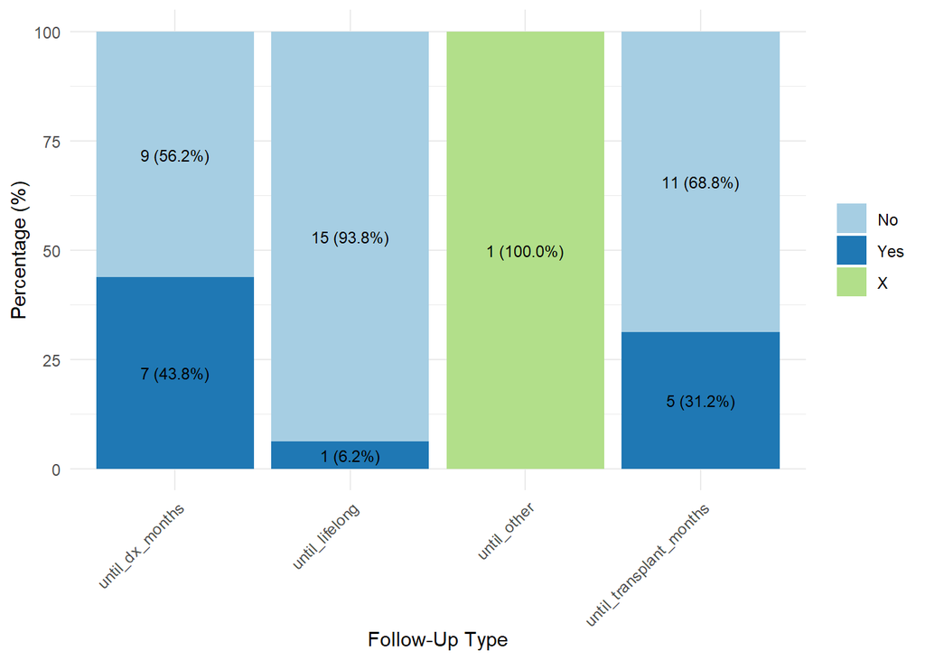

| Category | Comment |
| --- | --- |
| Dx Months | ~36 months |
| Dx Months | until end of year 4 (chemotherapy patients) |
| Dx Months | uptill 5 years after reaching CR |
| Dx Months | approximately 36-48 months |
| Dx Months | x1 at end of therapy |
| Dx Months | Knochenmark- und MRD-Kontrollen:  im 3. Jahr: weiter 3-monatlich, ca. Wo 143 und Woche 156 (Ende Jahr 3 nach ED)  im 4. Jahr: halbjährlich  Ab Jahr 5: keine weiteren MRD-Kontrollen |
| Dx Months | end of intensive chemotherapy (see question 16) |
| Transplant Months | Not fully standardized. Depends on MRD kinetics. |
| Transplant Months | approximately 36 months |
| Transplant Months | see above, in negative samples post-SCT last BM is 3 years post-SCT, after that yearly PB. But depends on the clinical situation and individual decision of physicians |
| Transplant Months | Knochenmark- und MRD-Kontrollen:  im 3. Jahr: weiter 3-monatlich, ca. Wo 143 und Woche 156 (Ende Jahr 3 nach ED)  im 4. Jahr: halbjährlich  Ab Jahr 5: keine weiteren MRD-Kontrollen |
| Transplant Months | 1 year |
| Lifelong | evry three months at 1st year, every six months for the 2nd year and then yearly up to 5 years |
| Other | evry three months at 1st year, every six months for the 2nd year and then yearly up to 5 years |

Statement 5: Bone marrow aspiration for relapse detection should be continued until 36–60 months after initial diagnosis.

Statement 6: Bone marrow aspiration for relapse detection should be continued until 36 months after stem cell transplantation.

## 4.6 What are the relevant MRD cut-off values used for relapse detection in **Ph-negative ALL**?

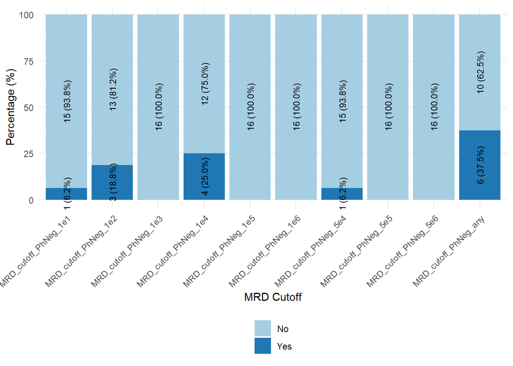

| Response | Answer |
| --- | --- |
| Other | Positivity below QR: warning signal, MRD >1XE-04: molecular relapse |
| Other | 5x10-2 |
| Other | any MRD positivity, but in positive not quantifiable verified by NGS |
| Other | Any MRD-positivity with further confirmation with other method and different sample |
| Other | We follow PDL guidelines |
| Other | For relapse definition more than 1 method is needed for confirmation, if MRD is < 5%. MRD of 5E-04 is highly suspicious of pending relapse if detected late in therapy |

Statement 7: For postremission relapse detection, any MRD positivity is considered relevant; however, values below 1×10⁻⁴ should be confirmed using an additional method and a second sample.

## 4.7 What are the relevant **IG/TR-based** MRD cut-off values used for relapse detection in **Ph-positive ALL**?

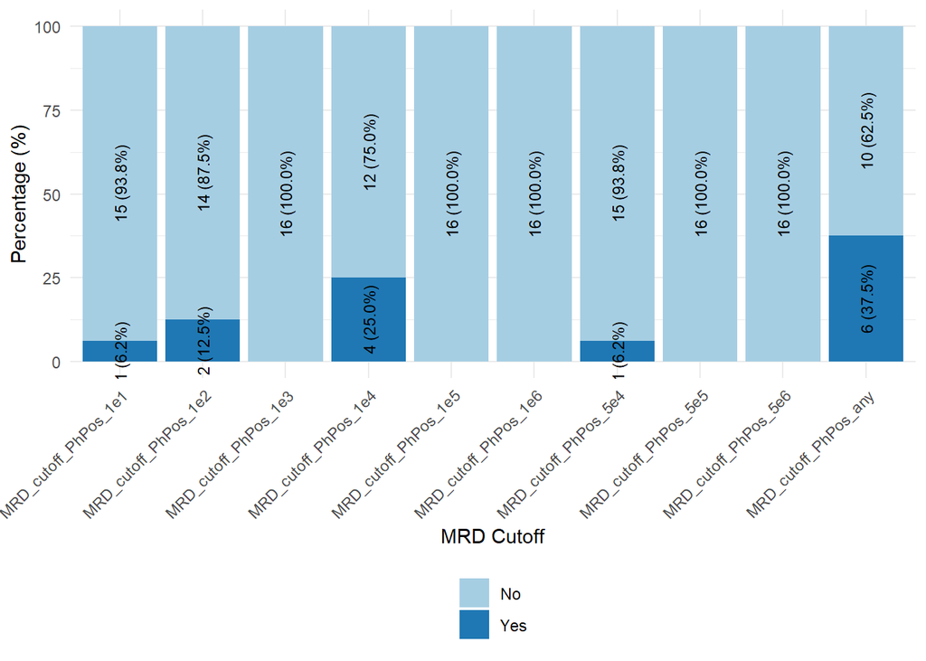

| Response | Answer |
| --- | --- |
| Other | not fully standardized, probably like in Ph-negative ALL. |
| Other | 5x10-2 |
| Other | we do BCR/ABL on DNA level simultaneously and solve individually (CML-like cases) |
| Other | Any MRD-positivity with further confirmation with other method and different sample |
| Other | We follow PDL guidelines |
| Other | do not use IG/TR-MRD; 1x10-2 for flow |
| Other | see question 18 |

## 4.8 What are the relevant **BCR::ABL1-based** MRD cut-off values used for relapse detection in **Ph-positive ALL**?

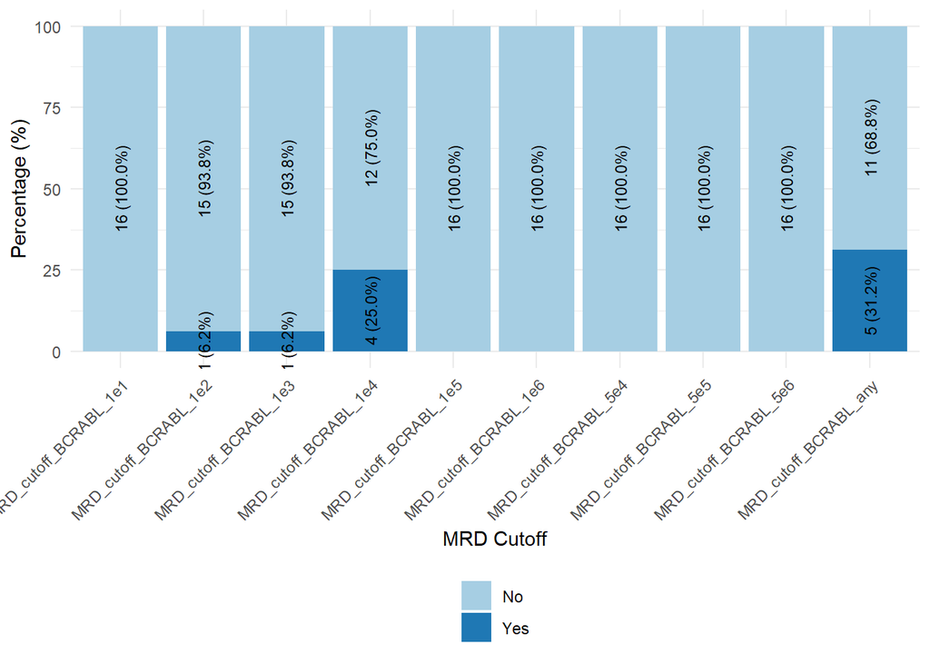

| Response | Answer |
| --- | --- |
| Other | Likely not relevant with IG/TR testing |
| Other | none |
| Other | reported in the context of simultaneous measurement of DNA-based BCR/ABL and Ig/TR (e.g. BCR/ABL 1E-02 and Ig/TR negative does not need to be relapse in CML-like cases) |
| Other | ALLIC group did not define MRD cut-off value for diagnosing molecular relapse in Ph+ALL. LOQ in CML is 1e-05 |
| Other | Any MRD-positivity with further confirmation with other method and different sample |
| Other | We follow PDL guidelines |
| Other | BCR::ABL1 positivity without Ig/TCR positivity and zytomorphological absence of blasts is not considered a relapse (this constellation is suspicious for misdiagnosis in the beginning –> CML in blasts … |

# 5 Relapse confirmation

## 5.1 Is a conversion to MRD-positivity considered equivalent to relapse?

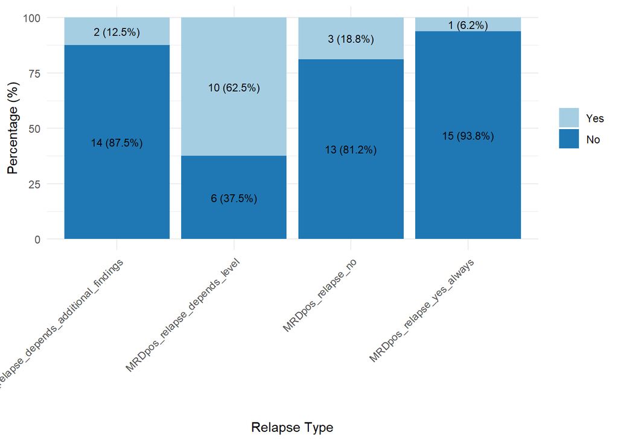

| Category | Comment |
| --- | --- |
| Yes, always | Yes if converts from negative to positive but only if there is high confidence that the finding reflects true MRD (e.g. not “background”), ideally confirmed on a follow-up sample. |
| Dependes on MRD level | If ther is higher than 1x10e-4, confirmed in a second sample |
| Dependes on MRD level | 1xE-04 |
| Dependes on MRD level | if >0,01% |
| Dependes on MRD level | 10-4 but this is defined then as molecular relapse which is different from hematologic relapse |
| Dependes on MRD level | Clearly if 1E-02, but it would trigger clinical actions if 1E-04 if confirmed by 2 tecniques in 2 different consecutive samples |
| Dependes on MRD level | 1x10-2 |
| Dependes on MRD level | one log increase required |
| Dependes on MRD level | ja, auf jeden Fall oberhalb des exakt messbaren Bereiches, unterhalb mindestens Kontrolle zeitnah empfohlen, hängt auch ab vom Niveau |
| Dependes on MRD level | MRD 1 -<5%: two other tests with >=1% or second BM. MRD <25% one additional test >= 1%. doi: 10.1182/blood.2021012328. PMID: 34192312; PMCID: PMC8952186. |
| No, never | depends on ALL type-different situation in CML-like ALL, see above. In Ph-neg ALL pos NQ after negative always verified by NGS |
| No, never | Only if MRD exceedes the 1% (1–02) limit for CR as defined by the P-d-L paper |
| Depends on additional findings | MRD-positivity conversion should be unambiguous: either high level, or if low, without any doubt (confirmed on a second sample or a second marker or technique, or with clinical signs of extramedullary… |
| Depends on additional findings | Flow or/and morphology |

Statement 8: Conversion to MRD positivity should be considered a relapse only if the MRD level exceeds 1×10⁻⁴ and is confirmed by an additional method or other molecular target.

## 5.2 Should the conversion from **IG/TR-based** MRD-negativity to MRD-positivity be confirmed by a consecutive sample?

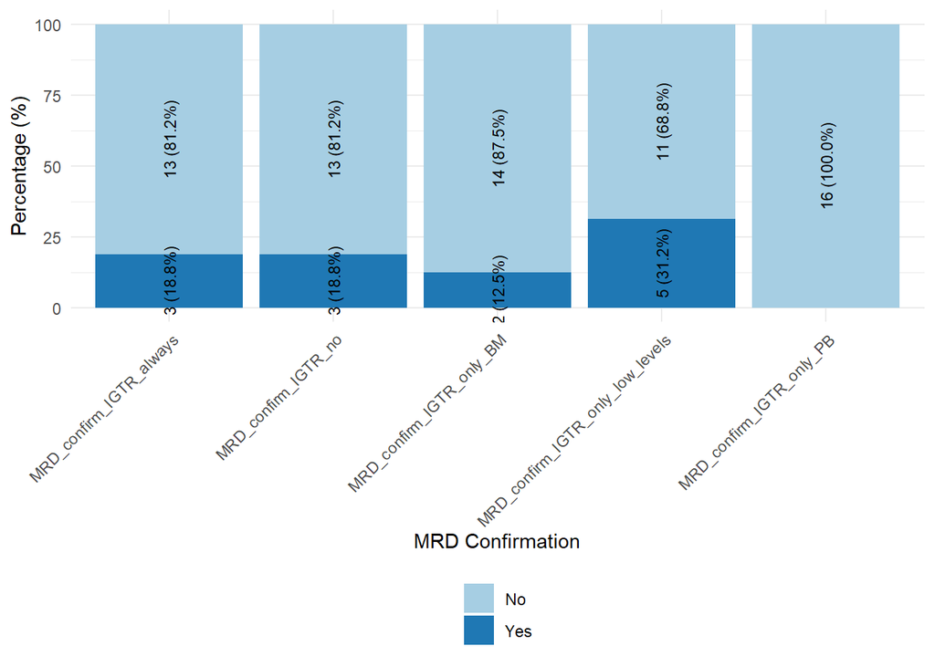

| Response | Answer |
| --- | --- |
| Other | depends on the context and MRD level |
| Other | We follow PdL so depends on if a confirmatory test and level of detection |
| Other | depends on the level <10-4 likely requires repeat |
| Other | No, a single positive result is sufficient: depends on the Level (see 21) |

Statement 9: Conversion from IG/TR-based MRD-negativity to MRD-positivity should be confirmed by a consecutive sample only if the MRD level is below 1×10⁻⁴.

## 5.3 Should the conversion from **BCR::ABL1-based** MRD-negativity to MRD-positivity be confirmed by a consecutive sample?

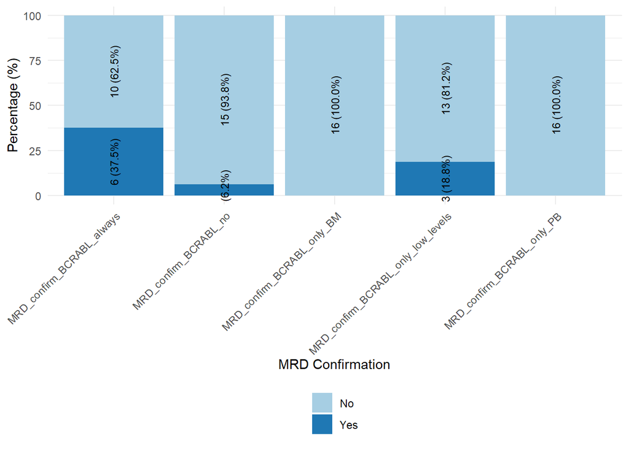

| Response | Answer |
| --- | --- |
| Other | Only if accompanied by MRD by IG/TR |
| Other | IG/TR to be analyzed |
| Other | Relapse should be confirmed by IG/TR MRD in bone marrow |
| Other | in CML like completely different situation, usually repeated sample necessary |
| Other | We follow PdL |
| Other | no routine BCR::ABL1 monitoring performed |

Statement 10: Conversion from BCR::ABL1-based MRD-negativity to MRD-positivity should be considered a relapse only if accompanied by IG/TR-based MRD positivity.

## 5.4 If MRD conversion requires confirmation, within what time frame should the consecutive sample be taken?

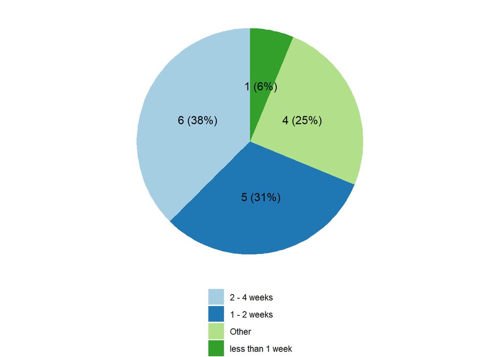

| Category | Comment |
| --- | --- |
| Other | No clear rule |
| Other | 2 weeks |
| Other | We follow PdL |
| Other | <1 week for positive >1% without morphology, 2-4 weeks for lower level |

Statement 11: If MRD conversion requires confirmation, the consecutive sample should be taken within 1–4 weeks.

# 6 Clinical consequences of postremission MRD reoccurence

## 6.1 What are the clinical consequences when MRD recurrence is detected **during first-line chemotherapy**?

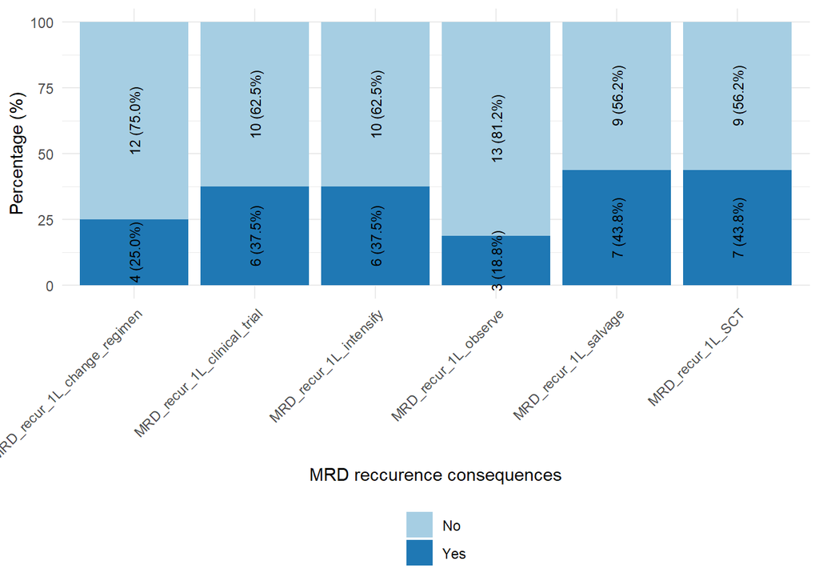

| Response | Answer |
| --- | --- |
| Other | it depends on MRD levels, frequently, a further BM is planned to monitor increase |
| Other | No defined rule, to be discussed |
| Other | depends on the protocol, usually SCT with salvage before |
| Other | It depends on the MRD level, time point and the clinical setting |
| Other | If meets PdL criteria for relapse we treat as a relapse |
| Other | abhängig vom Zeitpunkt des Auftretens und vom klinischen Bild des Patienten sowie der bisherigen Therapie unterschiedliche Antworten möglich |
| Other | answers depend of the level of MRD positivity: >=5E-04 after TP2 (day 78/92) Indication for alloHSCT and intensification of therapy. Below 5E-4: Obersevation without immediate intervention |

## 6.2 What are the clinical consequences when MRD recurrence is detected **after the end of first-line chemotherapy**?

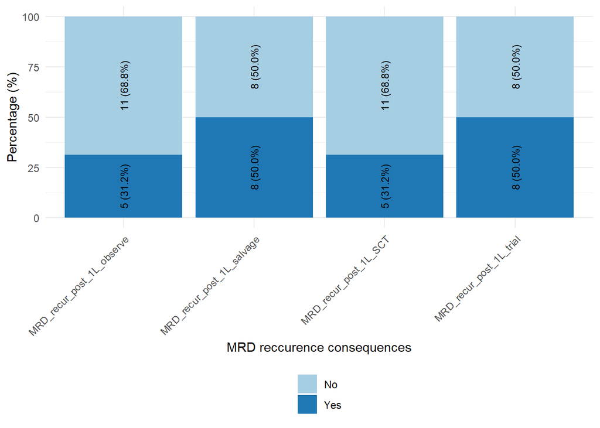

| Response | Answer |
| --- | --- |
| Other | depending on CR time, Relapse within 1 year: salvage; if CR>1 year first line induction rretarted |
| Other | A further BM is planned to monitor increase |
| Other | No defined rule, to be discussed |
| Other | not measured in non-HR patients, in HR patients is defined by protocol |
| Other | It depends on the MRD level, time point and the clinical setting |
| Other | If meets PdL criteria for relapse we treat as a relapse |
| Other | Mehrere Antworten möglich, da in Abhängigkeit des Alters, der Komorbiditäten, der bisherigen Erstlinientherapie sowie des MRD-Niveaus verschiedene Optionen möglich sind. |
| Other | it depends on the MRD level see question 25 |

## 6.3 What are the clinical consequences when MRD recurrence is detected **after stem cell transplantation**?

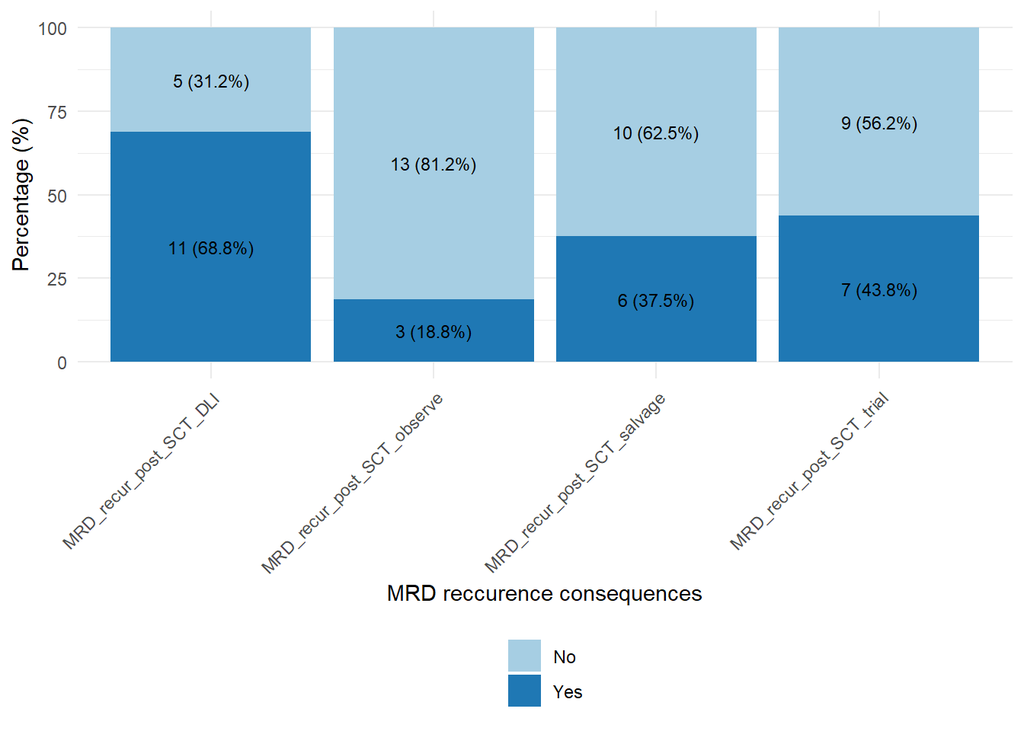

| Response | Answer |
| --- | --- |
| Other | not fully standardized |
| Other | if no GVHD: reduce immune suppression. Otherwise DLI or blina |
| Other | reduction of immunosuppression; short term confirmation of MRD increase on another BM sample |
| Other | based on the level-low MRD IST tapering, DLI, in high level CART, 2nd SCT.. |
| Other | Individual decision made by the transplant team |
| Other | It depends on the MRD level, time point and the clinical setting |
| Other | Depends on type of transplant, availability of DLI, ability to add a targeted or immunotherapeutic agent |
| Other | Mehrere Antworten möglich, da in Abhängigkeit des Alters, der Komorbiditäten, der bisherigen Erstlinientherapie sowie des MRD-Niveaus verschiedene Optionen möglich sind. |
| Other | it depends on the MRD level. Low positivity: reduction of Immunosuppression if possible, DLI |

# 7 Bone marrow sampling

Statement 12: Bone marrow should be used as the primary diagnostic sample.

Statement 13: For MRD assessment in BCP-ALL, bone marrow is preferred over peripheral blood.

Statement 14: In T-ALL, peripheral blood can be used as a substitute for bone marrow in MRD assessment.

## 7.1 In the clinical study your patients are treated in, is there a standard operation procedure (SOP) for bone marrow sampling?

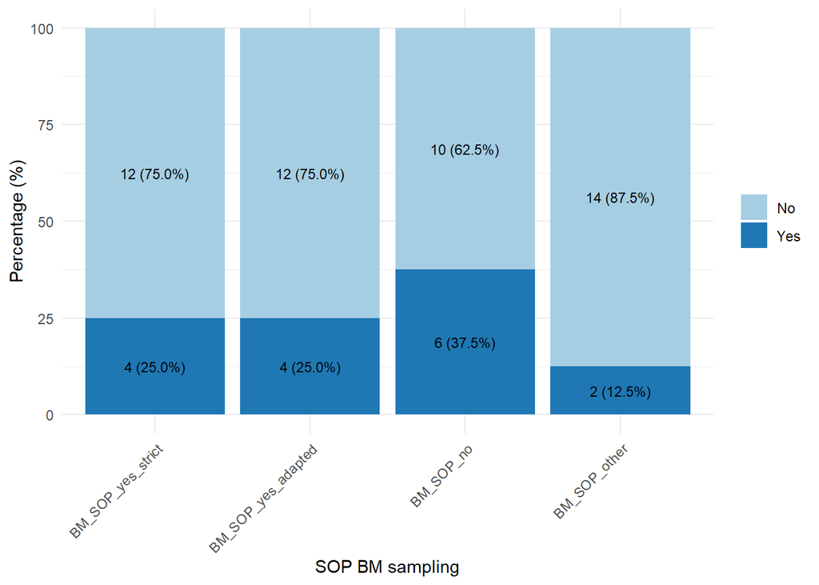

| Category | Comment |
| --- | --- |
| Other | There is a manual that states: 4.6.3 Material  10 ml Knochenmark und/oder 10 ml peripheres Blut  Von jedem Untersuchungszeitpunkt, möglichst 1. Aspirat  EDTA bevorzugt, Heparin auch möglich Die Zei… |
| Other | instructions are give in an extra document of the sample request form |

## 7.2 Apart from its use in diagnosing and classifying ALL, how else is diagnostic bone marrow aspirate utilized in clinical or research settings?

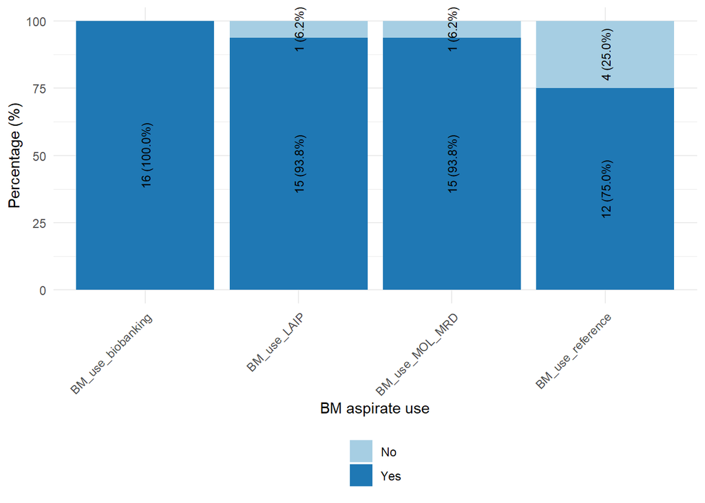

| Response | Answer |
| --- | --- |
| Other | research on add-on projects |
| Other | For pilot research purposes |
| Other | molecular genetics |

Statement 15: The diagnostic bone marrow sample is an essential reference material for molecular MRD assessment during follow-up and is also recommended as a reference for flow-cytometric MRD.

Statement 16: Beyond diagnosis and classification, diagnostic bone marrow aspirates should be used for LAIP identification, molecular MRD marker screening, as reference material for follow-up analyses, and biobanking.